# PRACTICA CALIFICADA N°3

Leonarddo Carlos López Solis 20232345

# CLEANING AND FORMATING

```python
import pandas as pd
linkEdu="https://github.com/LeonarddoCLS/PC3_20232345/raw/refs/heads/main/Education%20expenditures.csv"
linkElec="https://github.com/LeonarddoCLS/PC3_20232345/raw/refs/heads/main/Electricity%20-%20installed%20generating%20capacity.csv"
linkEnergy="https://github.com/LeonarddoCLS/PC3_20232345/raw/refs/heads/main/Energy%20consumption%20per%20capita.csv"
linkReserve="https://github.com/LeonarddoCLS/PC3_20232345/raw/refs/heads/main/Reserves%20of%20foreign%20exchange%20and%20gold.csv"

education=pd.read_csv(linkEdu)
electricity=pd.read_csv(linkElec)
energy=pd.read_csv(linkEnergy)
reserve=pd.read_csv(linkReserve)
```

En el caso existan valores perdidos, los eliminamos con este comando

```python
education_1 = education.dropna()
electricity_1 = electricity.dropna()
energy_1 = energy.dropna()
reserve_1 = reserve.dropna()
```

Detectamos que dos columns tienen leading space

```python
electricity_1.columns = electricity_1.columns.str.strip()
energy_1.columns = energy_1.columns.str.strip()
```

En caso hubieran duplicados en los países, los eliminamos de la siguiente forma comando

```python
delete_Duplicates = lambda df: df.drop_duplicates(subset=['name'])
delete_Duplicates(education_1)
delete_Duplicates(electricity_1)
delete_Duplicates(energy_1)
delete_Duplicates(reserve_1)
```

|  | name | slug | value | date_of_information | ranking | region |
| --- | --- | --- | --- | --- | --- | --- |
| 0 | China | china | $3,450,000,000,000 | 2023 | 1 | East and Southeast Asia |
| 1 | Japan | japan | $1,295,000,000,000 | 2023 | 2 | East and Southeast Asia |
| 2 | Switzerland | switzerland | $863,892,000,000 | 2023 | 3 | Europe |
| 3 | United States | united-states | $773,426,000,000 | 2023 | 4 | North America |
| 4 | India | india | $627,793,000,000 | 2023 | 5 | South Asia |
| ... | ... | ... | ... | ... | ... | ... |
| 190 | Anguilla | anguilla | $76,380,000 | 2017 | 191 | Central America and the Caribbean |
| 191 | Burkina Faso | burkina-faso | $49,000,000 | 2017 | 192 | Africa |
| 192 | Montserrat | montserrat | $47,580,000 | 2017 | 193 | Central America and the Caribbean |
| 193 | Sao Tome and Principe | sao-tome-and-principe | $46,247,000 | 2023 | 194 | Africa |
| 194 | Somalia | somalia | $30,450,000 | 2014 | 195 | Africa |

195 rows × 6 columns

---Primero eliminamos leading, tailing y espacios internos en blanco

```python
import re
clean_column_names = lambda df: df.columns.astype(str).str.strip().str.replace(pat=r'\s', repl='_', regex=True)

education_1.columns = clean_column_names(education_1)
electricity_1.columns = clean_column_names(electricity_1)
energy_1.columns = clean_column_names(energy_1)
reserve_1.columns = clean_column_names(reserve_1)
```

--- Limpiamos las columnas de variables tipo texto. Para ello, primero guardo el nombre de las "Column names"

```python
common_columns = set(education.columns.intersection(electricity.columns).intersection(energy.columns).intersection(reserve.columns))
common_text_columns=common_columns - {"date_of_information", "ranking"}
list_common_text=list(common_text_columns)
list_common_text
```

```
['region', 'name', 'slug']
```

```python
!pip install unidecode
```

```
Downloading Unidecode-1.4.0-py3-none-any.whl (235 kB)
   ━━━━━━━━━━━━━━━━━━━━━━━━━━━━━━━━━━━━━━━━ 235.8/235.8 kB 4.1 MB/s eta 0:00:00
```

Eliminamos caracteres non_ASCII utilizando unicode

```python
from unidecode import unidecode
apply_unidecode = lambda col:col.apply(unidecode).str.replace(pat='-', repl='_', regex=True)
education_1[list_common_text]=education_1.loc[:, list_common_text].apply(apply_unidecode)
electricity_1[list_common_text]=electricity_1.loc[:, list_common_text].apply(apply_unidecode)
energy_1[list_common_text]=energy_1.loc[:, list_common_text].apply(apply_unidecode)
reserve_1[list_common_text]=reserve_1.loc[:, list_common_text].apply(apply_unidecode)

first_group=["name", "region"]
turn_mayus=lambda col:col.str.upper()
education_1[first_group]=education_1.loc[:,first_group ].apply(turn_mayus)
electricity_1[first_group]=electricity_1.loc[:,first_group ].apply(turn_mayus)
energy_1[first_group]=energy_1.loc[:,first_group ].apply(turn_mayus)
reserve_1[first_group]=reserve_1.loc[:, first_group].apply(turn_mayus)
```

Limpiamos columnas numéricas

```python
get_numeric_colums= lambda df:list(set(df.columns)-set(common_text_columns))
education_1_numeric=get_numeric_colums(education_1)
electricity_1_numeric=get_numeric_colums(electricity_1)
energy_1_numeric=get_numeric_colums(energy_1)
reserve_1_numeric=get_numeric_colums(reserve_1)
```

```python
apply_pd_numeric=lambda col:col.astype(str).str.replace(pat=',|\$', repl='', regex=True).apply(pd.to_numeric)


education_1[education_1_numeric]=education_1.loc[:,education_1_numeric].apply(apply_pd_numeric)
electricity_1[electricity_1_numeric]=electricity_1.loc[:,electricity_1_numeric].apply(apply_pd_numeric)
energy_1[energy_1_numeric]=energy_1.loc[:,energy_1_numeric].apply(apply_pd_numeric)
reserve_1[reserve_1_numeric]=reserve_1.loc[:,reserve_1_numeric].apply(apply_pd_numeric)
```

# APPLYING FUZZY MERGING APPROACH:

Se eligió esta estrategia debido a que es la que permite recuperar un número mayor de casos al aplicar el merging.

1. Eliminamos la columna slug y date_of_information, con el fin de quedarnos solo con las variables principales

```python
delete_date = lambda df: df.drop(columns=['date_of_information']).drop(columns=['ranking']).drop(columns=['slug'])
education_1=delete_date(education_1)
electricity_1=delete_date(electricity_1)
energy_1=delete_date(energy_1)
reserve_1=delete_date(reserve_1)
```

2. Mejorando los nombres de ciertas columnas para diferenciarlas o esclarecer el significado del valor

```python
education_1 = education_1.rename(columns={'%_of_GDP':'education_expenditure(%GDP)'})
electricity_1 = electricity_1.rename(columns={'kW':'power_generation(kW)'})
energy_1 = energy_1.rename(columns={'Btu/person':'Btu/person_consumption($)'})
reserve_1 = reserve_1.rename(columns={'value':'financial_assets_value($)'})
```

3. Empezamos a hacer merge a education_1 y electricity_1

3.1) Visualizamos que países se encuentran en únicamente en el primer o el segundo dataframe

```python
only_education=set(education_1.name)-set(electricity_1.name)
only_education
```

```
{'ANDORRA',
 'ANGUILLA',
 'CURACAO',
 'LIECHTENSTEIN',
 'MARSHALL ISLANDS',
 'MICRONESIA, FEDERATED STATES OF',
 'MONACO',
 'PALAU',
 'SAN MARINO'}
```

```python
only_electricity=set(electricity_1.name)-set(education_1.name)
only_electricity
```

```
{'AMERICAN SAMOA',
 'BOSNIA AND HERZEGOVINA',
 'CUBA',
 'EQUATORIAL GUINEA',
 'ERITREA',
 'FALKLAND ISLANDS (ISLAS MALVINAS)',
 'FRENCH POLYNESIA',
 'GIBRALTAR',
 'GUAM',
 'KOREA, NORTH',
 'KOSOVO',
 'LIBYA',
 'MONTENEGRO',
 'NEW CALEDONIA',
 'NIUE',
 'NORTH MACEDONIA',
 'SAINT HELENA, ASCENSION, AND TRISTAN DA CUNHA',
 'SAINT PIERRE AND MIQUELON',
 'SUDAN',
 'SYRIA',
 'TAIWAN',
 'VIRGIN ISLANDS',
 'YEMEN'}
```

3.2) Aplicamos el enfoque thefuzz para ver posibles pares de países que sean compatibles

```python
!pip install thefuzz
```

```
Downloading thefuzz-0.22.1-py3-none-any.whl (8.2 kB)
Downloading rapidfuzz-3.13.0-cp311-cp311-manylinux_2_17_x86_64.manylinux2014_x86_64.whl (3.1 MB)
   ━━━━━━━━━━━━━━━━━━━━━━━━━━━━━━━━━━━━━━━━ 3.1/3.1 MB 20.1 MB/s eta 0:00:00
```

```python
from thefuzz import process as fz
[(c,fz.extractOne(c,only_education )) for c in sorted(only_electricity)]
```

```
[('AMERICAN SAMOA', ('MONACO', 60)),
 ('BOSNIA AND HERZEGOVINA', ('ANDORRA', 53)),
 ('CUBA', ('CURACAO', 68)),
 ('EQUATORIAL GUINEA', ('PALAU', 54)),
 ('ERITREA', ('MICRONESIA, FEDERATED STATES OF', 51)),
 ('FALKLAND ISLANDS (ISLAS MALVINAS)', ('MARSHALL ISLANDS', 86)),
 ('FRENCH POLYNESIA', ('MICRONESIA, FEDERATED STATES OF', 48)),
 ('GIBRALTAR', ('PALAU', 54)),
 ('GUAM', ('ANGUILLA', 50)),
 ('KOREA, NORTH', ('ANDORRA', 51)),
 ('KOSOVO', ('MICRONESIA, FEDERATED STATES OF', 36)),
 ('LIBYA', ('LIECHTENSTEIN', 51)),
 ('MONTENEGRO', ('MONACO', 60)),
 ('NEW CALEDONIA', ('MONACO', 54)),
 ('NIUE', ('LIECHTENSTEIN', 51)),
 ('NORTH MACEDONIA', ('MONACO', 60)),
 ('SAINT HELENA, ASCENSION, AND TRISTAN DA CUNHA', ('ANDORRA', 57)),
 ('SAINT PIERRE AND MIQUELON', ('SAN MARINO', 51)),
 ('SUDAN', ('SAN MARINO', 68)),
 ('SYRIA', ('MICRONESIA, FEDERATED STATES OF', 54)),
 ('TAIWAN', ('LIECHTENSTEIN', 54)),
 ('VIRGIN ISLANDS', ('MARSHALL ISLANDS', 63)),
 ('YEMEN', ('LIECHTENSTEIN', 45))]
```

3.3)Dado que el máximo porcentaje de similitud en realidad no corresponde a nombres compatibles y que no se visualiza ningún otro caso compatible, se verificará en la otra dirección sin recuperar ninguno

```python
[(c,fz.extractOne(c,only_electricity )) for c in sorted(only_education)]
```

```
[('ANDORRA', ('SAINT HELENA, ASCENSION, AND TRISTAN DA CUNHA', 57)),
 ('ANGUILLA', ('FALKLAND ISLANDS (ISLAS MALVINAS)', 56)),
 ('CURACAO', ('CUBA', 68)),
 ('LIECHTENSTEIN', ('TAIWAN', 54)),
 ('MARSHALL ISLANDS', ('FALKLAND ISLANDS (ISLAS MALVINAS)', 86)),
 ('MICRONESIA, FEDERATED STATES OF', ('SYRIA', 54)),
 ('MONACO', ('MONTENEGRO', 60)),
 ('PALAU', ('FALKLAND ISLANDS (ISLAS MALVINAS)', 54)),
 ('SAN MARINO', ('SUDAN', 68))]
```

En ninguno de los dos casos hay paises compatibles

3.4)Eliminaremos todos esas filas, debido a que no se tendría información completa para ninguno de esos casos

```python
only_education = list(only_education)
only_electricity = list(only_electricity)
education_2 = education_1[~education_1['name'].isin(only_education)]
electricity_2 = electricity_1[~electricity_1['name'].isin(only_electricity)]
```

3.5) Dado que ahora ambos tienen las mismas filas, aplicaremos merging left join. Se puede elegir, cualquiera de los otros 3 tipos: inner join, right join, outer join.

```python
first_merge=education_2.merge(electricity_2, how='left', left_on='name', right_on='name')
first_merge=first_merge.drop(columns=['region_y'])
first_merge
```

|  | name | education_expenditure(%GDP) | region_x | power_generation(kW) |
| --- | --- | --- | --- | --- |
| 0 | SOLOMON ISLANDS | 12.8 | AUSTRALIA AND OCEANIA | 37000 |
| 1 | KIRIBATI | 12.4 | AUSTRALIA AND OCEANIA | 12000 |
| 2 | GREENLAND | 10.2 | NORTH AMERICA | 190000 |
| 3 | BOLIVIA | 9.8 | SOUTH AMERICA | 4375000 |
| 4 | NAMIBIA | 9.6 | AFRICA | 646000 |
| ... | ... | ... | ... | ... |
| 183 | HAITI | 1.4 | CENTRAL AMERICA AND THE CARIBBEAN | 472000 |
| 184 | PAPUA NEW GUINEA | 1.4 | EAST AND SOUTHEAST ASIA | 1148000 |
| 185 | VENEZUELA | 1.3 | SOUTH AMERICA | 33493000 |
| 186 | NIGERIA | 0.5 | AFRICA | 4094000 |
| 187 | SOMALIA | 0.3 | AFRICA | 156000 |

188 rows × 4 columns

4. Continuamos con merge entre energy y reserve

4.1) Visualizamos que países se encuentran en únicamente en el primer o el segundo dataframe

```python
only_energy=set(energy_1.name)-set(reserve_1.name)
only_energy
```

```
{'AMERICAN SAMOA',
 'BERMUDA',
 'BRITISH VIRGIN ISLANDS',
 'GUAM',
 'KIRIBATI',
 'KOREA, NORTH',
 'PUERTO RICO'}
```

```python
only_reserve=set(reserve_1.name)-set(energy_1.name)
only_reserve
```

```
{'ANGUILLA',
 'ICELAND',
 'MICRONESIA, FEDERATED STATES OF',
 'MONTSERRAT',
 'PALAU',
 'SAN MARINO',
 'TRINIDAD AND TOBAGO'}
```

4.2) Aplicamos el enfoque thefuzz para ver posibles pares de países que sean compatibles

```python
[(c,fz.extractOne(c,only_energy )) for c in sorted(only_reserve)]
```

```
[('ANGUILLA', ('GUAM', 50)),
 ('ICELAND', ('BRITISH VIRGIN ISLANDS', 64)),
 ('MICRONESIA, FEDERATED STATES OF', ('PUERTO RICO', 47)),
 ('MONTSERRAT', ('KOREA, NORTH', 36)),
 ('PALAU', ('PUERTO RICO', 51)),
 ('SAN MARINO', ('AMERICAN SAMOA', 55)),
 ('TRINIDAD AND TOBAGO', ('KIRIBATI', 43))]
```

4.3) Dado que el máximo porcentaje de similitud en realidad no corresponde a nombres compatibles y que no se visualiza ningún otro caso compatible, se verificará en la otra dirección sin recuperar ninguno

```python
[(c,fz.extractOne(c,only_reserve )) for c in sorted(only_energy)]
```

```
[('AMERICAN SAMOA', ('SAN MARINO', 55)),
 ('BERMUDA', ('MICRONESIA, FEDERATED STATES OF', 39)),
 ('BRITISH VIRGIN ISLANDS', ('ICELAND', 64)),
 ('GUAM', ('ANGUILLA', 50)),
 ('KIRIBATI', ('MICRONESIA, FEDERATED STATES OF', 43)),
 ('KOREA, NORTH', ('MICRONESIA, FEDERATED STATES OF', 39)),
 ('PUERTO RICO', ('PALAU', 51))]
```

4.4) En ambos casos no existe un par compatible, por lo que se procesderá a borrar todas esas filas de only_energy y only_reserve

```python
only_energy = list(only_energy)
only_reserve = list(only_reserve)
energy_2 = energy_1[~energy_1['name'].isin(only_energy)]
reserve_2 = reserve_1[~reserve_1['name'].isin(only_reserve)]
```

```python
second_merge=energy_2.merge(reserve_2, how='left', left_on='name', right_on='name')
second_merge=second_merge.drop(columns=['region_y'])
second_merge
```

|  | name | Btu/person_consumption($) | region_x | financial_assets_value($) |
| --- | --- | --- | --- | --- |
| 0 | QATAR | 814308000 | MIDDLE EAST | 51539000000 |
| 1 | SINGAPORE | 643259000 | EAST AND SOUTHEAST ASIA | 359835000000 |
| 2 | BAHRAIN | 554202000 | MIDDLE EAST | 5118000000 |
| 3 | UNITED ARAB EMIRATES | 450432000 | MIDDLE EAST | 189491000000 |
| 4 | BRUNEI | 403365000 | EAST AND SOUTHEAST ASIA | 4483000000 |
| ... | ... | ... | ... | ... |
| 183 | CHAD | 1502000 | AFRICA | 211591000 |
| 184 | CONGO, DEMOCRATIC REPUBLIC OF THE | 1305000 | AFRICA | 5104000000 |
| 185 | CENTRAL AFRICAN REPUBLIC | 954000 | AFRICA | 374405000 |
| 186 | BURUNDI | 946000 | AFRICA | 90350000 |
| 187 | SOMALIA | 649000 | AFRICA | 30450000 |

188 rows × 4 columns

5. Finalmente, aplicamos merge para second_merge y first_merge

5.1) Visualizamos que países se encuentran en únicamente en el primer o el segundo dataframe

```python
only_first=set(first_merge.name)-set(second_merge.name)
only_first
```

```
{'BERMUDA',
 'BRITISH VIRGIN ISLANDS',
 'COOK ISLANDS',
 'FAROE ISLANDS',
 'GREENLAND',
 'ICELAND',
 'KIRIBATI',
 'MONTSERRAT',
 'NAURU',
 'PUERTO RICO',
 'TRINIDAD AND TOBAGO',
 'TURKS AND CAICOS ISLANDS'}
```

```python
only_second=set(second_merge.name)-set(first_merge.name)
only_second
```

```
{'BOSNIA AND HERZEGOVINA',
 'CUBA',
 'EQUATORIAL GUINEA',
 'ERITREA',
 'KOSOVO',
 'LIBYA',
 'MONTENEGRO',
 'NORTH MACEDONIA',
 'SUDAN',
 'SYRIA',
 'TAIWAN',
 'YEMEN'}
```

5.2) Aplicamos el enfoque thefuzz para ver posibles pares de países que sean compatibles

```python
[(c,fz.extractOne(c,only_first )) for c in sorted(only_second)]
```

```
[('BOSNIA AND HERZEGOVINA', ('ICELAND', 51)),
 ('CUBA', ('BERMUDA', 51)),
 ('EQUATORIAL GUINEA', ('ICELAND', 49)),
 ('ERITREA', ('PUERTO RICO', 51)),
 ('KOSOVO', ('TURKS AND CAICOS ISLANDS', 43)),
 ('LIBYA', ('KIRIBATI', 54)),
 ('MONTENEGRO', ('MONTSERRAT', 60)),
 ('NORTH MACEDONIA', ('NAURU', 45)),
 ('SUDAN', ('TURKS AND CAICOS ISLANDS', 54)),
 ('SYRIA', ('KIRIBATI', 54)),
 ('TAIWAN', ('TRINIDAD AND TOBAGO', 54)),
 ('YEMEN', ('GREENLAND', 54))]
```

5.3) Dado que el máximo porcentaje de similitud en realidad no corresponde a nombres compatibles y que no se visualiza ningún otro caso compatible, se verificará en la otra dirección sin recuperar ninguno

```python
[(c,fz.extractOne(c,only_second )) for c in sorted(only_first)]
```

```
[('BERMUDA', ('CUBA', 51)),
 ('BRITISH VIRGIN ISLANDS', ('SUDAN', 54)),
 ('COOK ISLANDS', ('SUDAN', 54)),
 ('FAROE ISLANDS', ('SUDAN', 54)),
 ('GREENLAND', ('YEMEN', 54)),
 ('ICELAND', ('BOSNIA AND HERZEGOVINA', 51)),
 ('KIRIBATI', ('LIBYA', 54)),
 ('MONTSERRAT', ('MONTENEGRO', 60)),
 ('NAURU', ('BOSNIA AND HERZEGOVINA', 51)),
 ('PUERTO RICO', ('ERITREA', 51)),
 ('TRINIDAD AND TOBAGO', ('SUDAN', 54)),
 ('TURKS AND CAICOS ISLANDS', ('SUDAN', 54))]
```

5.4) En ambos casos no existe un par compatible, por lo que se procesderá a borrar todas esas filas de first and second merge

```python
only_first = list(only_first)
only_second = list(only_second)
first_merge = first_merge[~first_merge['name'].isin(only_first)]
# Filter the second_merge DataFrame using the boolean Series
second_merge = second_merge[~second_merge['name'].isin(only_second)]
```

```python
final_merge=first_merge.merge(second_merge, how='left', left_on='name', right_on='name')
final_merge=final_merge.drop(columns=['region_x_y'])
final_merge
```

|  | name | education_expenditure(%GDP) | region_x_x | power_generation(kW) | Btu/person_consumption($) | financial_assets_value($) |
| --- | --- | --- | --- | --- | --- | --- |
| 0 | SOLOMON ISLANDS | 12.8 | AUSTRALIA AND OCEANIA | 37000 | 5655000 | 688220000 |
| 1 | BOLIVIA | 9.8 | SOUTH AMERICA | 4375000 | 29340000 | 1800000000 |
| 2 | NAMIBIA | 9.6 | AFRICA | 646000 | 21734000 | 2956000000 |
| 3 | SIERRA LEONE | 9.1 | AFRICA | 149000 | 2301000 | 495699000 |
| 4 | BELIZE | 8.7 | CENTRAL AMERICA AND THE CARIBBEAN | 220000 | 30752000 | 473729000 |
| ... | ... | ... | ... | ... | ... | ... |
| 171 | HAITI | 1.4 | CENTRAL AMERICA AND THE CARIBBEAN | 472000 | 3486000 | 2586000000 |
| 172 | PAPUA NEW GUINEA | 1.4 | EAST AND SOUTHEAST ASIA | 1148000 | 8781000 | 3901000000 |
| 173 | VENEZUELA | 1.3 | SOUTH AMERICA | 33493000 | 54474000 | 9794000000 |
| 174 | NIGERIA | 0.5 | AFRICA | 4094000 | 7993000 | 35564000000 |
| 175 | SOMALIA | 0.3 | AFRICA | 156000 | 649000 | 30450000 |

176 rows × 6 columns

6. Finalmente hacemos unos últimos arreglos a los nombres de las columnas

```python
final_merge= final_merge.rename(columns={'name': 'Country'})
final_merge= final_merge.rename(columns={'region_x_x': 'Region'})
```

```python
region = final_merge['Region']
final_merge=final_merge.drop(columns=['Region'])
final_merge.insert(1, 'Region', region)
```

Guardamos una copia para no regresar hasta el inicio

```python
my_dataframe=final_merge.copy()
my_dataframe
```

|  | Country | Region | education_expenditure(%GDP) | power_generation(kW) | Btu/person_consumption($) | financial_assets_value($) |
| --- | --- | --- | --- | --- | --- | --- |
| 0 | SOLOMON ISLANDS | AUSTRALIA AND OCEANIA | 12.8 | 37000 | 5655000 | 688220000 |
| 1 | BOLIVIA | SOUTH AMERICA | 9.8 | 4375000 | 29340000 | 1800000000 |
| 2 | NAMIBIA | AFRICA | 9.6 | 646000 | 21734000 | 2956000000 |
| 3 | SIERRA LEONE | AFRICA | 9.1 | 149000 | 2301000 | 495699000 |
| 4 | BELIZE | CENTRAL AMERICA AND THE CARIBBEAN | 8.7 | 220000 | 30752000 | 473729000 |
| ... | ... | ... | ... | ... | ... | ... |
| 171 | HAITI | CENTRAL AMERICA AND THE CARIBBEAN | 1.4 | 472000 | 3486000 | 2586000000 |
| 172 | PAPUA NEW GUINEA | EAST AND SOUTHEAST ASIA | 1.4 | 1148000 | 8781000 | 3901000000 |
| 173 | VENEZUELA | SOUTH AMERICA | 1.3 | 33493000 | 54474000 | 9794000000 |
| 174 | NIGERIA | AFRICA | 0.5 | 4094000 | 7993000 | 35564000000 |
| 175 | SOMALIA | AFRICA | 0.3 | 156000 | 649000 | 30450000 |

176 rows × 6 columns

# REPORT AVERAGE, MIN AND MAX VALUES

Primera variable: education_expenditure(%GDP)

```python
#Mostarmos el valor máximo
my_dataframe.loc[my_dataframe.groupby('Region')['education_expenditure(%GDP)'].idxmax()][['Country', 'Region', 'education_expenditure(%GDP)']]
```

|  | Country | Region | education_expenditure(%GDP) |
| --- | --- | --- | --- |
| 2 | NAMIBIA | AFRICA | 9.6 |
| 0 | SOLOMON ISLANDS | AUSTRALIA AND OCEANIA | 12.8 |
| 4 | BELIZE | CENTRAL AMERICA AND THE CARIBBEAN | 8.7 |
| 27 | KYRGYZSTAN | CENTRAL ASIA | 6.2 |
| 26 | MACAU | EAST AND SOUTHEAST ASIA | 6.3 |
| 10 | SWEDEN | EUROPE | 7.2 |
| 7 | SAUDI ARABIA | MIDDLE EAST | 7.8 |
| 30 | UNITED STATES | NORTH AMERICA | 6.1 |
| 1 | BOLIVIA | SOUTH AMERICA | 9.8 |
| 13 | BHUTAN | SOUTH ASIA | 7.0 |

```python
#Mostramos el valor mínimo
my_dataframe.loc[my_dataframe.groupby('Region')['education_expenditure(%GDP)'].idxmin()][['Country', 'Region', 'education_expenditure(%GDP)']]
```

|  | Country | Region | education_expenditure(%GDP) |
| --- | --- | --- | --- |
| 175 | SOMALIA | AFRICA | 0.3 |
| 160 | VANUATU | AUSTRALIA AND OCEANIA | 2.2 |
| 171 | HAITI | CENTRAL AMERICA AND THE CARIBBEAN | 1.4 |
| 149 | ARMENIA | CENTRAL ASIA | 2.8 |
| 172 | PAPUA NEW GUINEA | EAST AND SOUTHEAST ASIA | 1.4 |
| 137 | ALBANIA | EUROPE | 3.1 |
| 169 | LEBANON | MIDDLE EAST | 1.7 |
| 94 | MEXICO | NORTH AMERICA | 4.3 |
| 173 | VENEZUELA | SOUTH AMERICA | 1.3 |
| 167 | SRI LANKA | SOUTH ASIA | 1.9 |

```python
#Mostramos la media
my_dataframe.groupby('Region', as_index=False)['education_expenditure(%GDP)'].mean()
```

|  | Region | education_expenditure(%GDP) |
| --- | --- | --- |
| 0 | AFRICA | 4.268000 |
| 1 | AUSTRALIA AND OCEANIA | 6.314286 |
| 2 | CENTRAL AMERICA AND THE CARIBBEAN | 4.555000 |
| 3 | CENTRAL ASIA | 4.333333 |
| 4 | EAST AND SOUTHEAST ASIA | 3.633333 |
| 5 | EUROPE | 5.151429 |
| 6 | MIDDLE EAST | 4.528571 |
| 7 | NORTH AMERICA | 5.200000 |
| 8 | SOUTH AMERICA | 4.808333 |
| 9 | SOUTH ASIA | 3.850000 |

Segunda varaible: power_generation(kW)

```python
#Mostarmos el valor máximo
my_dataframe.loc[my_dataframe.groupby('Region')['power_generation(kW)'].idxmax()][['Country', 'Region', 'power_generation(kW)']]
```

|  | Country | Region | power_generation(kW) |
| --- | --- | --- | --- |
| 17 | SOUTH AFRICA | AFRICA | 65989000 |
| 28 | AUSTRALIA | AUSTRALIA AND OCEANIA | 108193000 |
| 81 | DOMINICAN REPUBLIC | CENTRAL AMERICA AND THE CARIBBEAN | 6581000 |
| 117 | RUSSIA | CENTRAL ASIA | 301926000 |
| 118 | CHINA | EAST AND SOUTHEAST ASIA | 2949000000 |
| 78 | GERMANY | EUROPE | 275658000 |
| 7 | SAUDI ARABIA | MIDDLE EAST | 119620000 |
| 30 | UNITED STATES | NORTH AMERICA | 1235000000 |
| 31 | BRAZIL | SOUTH AMERICA | 240251000 |
| 87 | INDIA | SOUTH ASIA | 499136000 |

```python
#Mostramos el valor mínimo
my_dataframe.loc[my_dataframe.groupby('Region')['power_generation(kW)'].idxmin()][['Country', 'Region', 'power_generation(kW)']]
```

|  | Country | Region | power_generation(kW) |
| --- | --- | --- | --- |
| 62 | SAO TOME AND PRINCIPE | AFRICA | 29000 |
| 18 | TONGA | AUSTRALIA AND OCEANIA | 34000 |
| 47 | DOMINICA | CENTRAL AMERICA AND THE CARIBBEAN | 41000 |
| 27 | KYRGYZSTAN | CENTRAL ASIA | 3944000 |
| 96 | TIMOR_LESTE | EAST AND SOUTHEAST ASIA | 277000 |
| 23 | MOLDOVA | EUROPE | 779000 |
| 54 | WEST BANK | MIDDLE EAST | 352000 |
| 94 | MEXICO | NORTH AMERICA | 105586000 |
| 86 | GUYANA | SOUTH AMERICA | 259000 |
| 40 | MALDIVES | SOUTH ASIA | 432000 |

```python
#Mostramos la media
my_dataframe.groupby('Region', as_index=False)['power_generation(kW)'].mean()
```

|  | Region | power_generation(kW) |
| --- | --- | --- |
| 0 | AFRICA | 4.619820e+06 |
| 1 | AUSTRALIA AND OCEANIA | 1.706100e+07 |
| 2 | CENTRAL AMERICA AND THE CARIBBEAN | 1.580500e+06 |
| 3 | CENTRAL ASIA | 4.239578e+07 |
| 4 | EAST AND SOUTHEAST ASIA | 2.108446e+08 |
| 5 | EUROPE | 4.027509e+07 |
| 6 | MIDDLE EAST | 3.381729e+07 |
| 7 | NORTH AMERICA | 5.008580e+08 |
| 8 | SOUTH AMERICA | 3.550408e+07 |
| 9 | SOUTH ASIA | 7.211612e+07 |

Tercera variable: Btu/person_consumption($)

```python
#Mostarmos el valor máximo
my_dataframe.loc[my_dataframe.groupby('Region')['Btu/person_consumption($)'].idxmax()][['Country', 'Region', 'Btu/person_consumption($)']]
```

|  | Country | Region | Btu/person_consumption($) |
| --- | --- | --- | --- |
| 56 | SEYCHELLES | AFRICA | 98847000 |
| 28 | AUSTRALIA | AUSTRALIA AND OCEANIA | 223158000 |
| 44 | ARUBA | CENTRAL AMERICA AND THE CARIBBEAN | 153952000 |
| 136 | TURKMENISTAN | CENTRAL ASIA | 261142000 |
| 147 | SINGAPORE | EAST AND SOUTHEAST ASIA | 643259000 |
| 35 | MALTA | EUROPE | 234698000 |
| 132 | QATAR | MIDDLE EAST | 814308000 |
| 59 | CANADA | NORTH AMERICA | 311599000 |
| 68 | ARGENTINA | SOUTH AMERICA | 78496000 |
| 13 | BHUTAN | SOUTH ASIA | 64082000 |

```python
#Mostramos el valor mínimo
my_dataframe.loc[my_dataframe.groupby('Region')['Btu/person_consumption($)'].idxmin()][['Country', 'Region', 'Btu/person_consumption($)']]
```

|  | Country | Region | Btu/person_consumption($) |
| --- | --- | --- | --- |
| 175 | SOMALIA | AFRICA | 649000 |
| 0 | SOLOMON ISLANDS | AUSTRALIA AND OCEANIA | 5655000 |
| 171 | HAITI | CENTRAL AMERICA AND THE CARIBBEAN | 3486000 |
| 37 | TAJIKISTAN | CENTRAL ASIA | 16192000 |
| 96 | TIMOR_LESTE | EAST AND SOUTHEAST ASIA | 6825000 |
| 137 | ALBANIA | EUROPE | 27407000 |
| 54 | WEST BANK | MIDDLE EAST | 14991000 |
| 94 | MEXICO | NORTH AMERICA | 57539000 |
| 130 | PARAGUAY | SOUTH AMERICA | 25733000 |
| 145 | AFGHANISTAN | SOUTH ASIA | 3380000 |

```python
#Mostramos la media
my_dataframe.groupby('Region', as_index=False)['Btu/person_consumption($)'].mean()
```

|  | Region | Btu/person_consumption($) |
| --- | --- | --- |
| 0 | AFRICA | 1.412284e+07 |
| 1 | AUSTRALIA AND OCEANIA | 6.221671e+07 |
| 2 | CENTRAL AMERICA AND THE CARIBBEAN | 5.587300e+07 |
| 3 | CENTRAL ASIA | 1.039161e+08 |
| 4 | EAST AND SOUTHEAST ASIA | 1.186874e+08 |
| 5 | EUROPE | 1.131422e+08 |
| 6 | MIDDLE EAST | 2.406509e+08 |
| 7 | NORTH AMERICA | 2.158707e+08 |
| 8 | SOUTH AMERICA | 4.641467e+07 |
| 9 | SOUTH ASIA | 2.350638e+07 |

Cuarta variable: financial_assets_value($)

```python
#Mostarmos el valor máximo
my_dataframe.loc[my_dataframe.groupby('Region')['financial_assets_value($)'].idxmax()][['Country', 'Region', 'financial_assets_value($)']]
```

|  | Country | Region | financial_assets_value($) |
| --- | --- | --- | --- |
| 12 | ALGERIA | AFRICA | 81217000000 |
| 28 | AUSTRALIA | AUSTRALIA AND OCEANIA | 61703000000 |
| 141 | GUATEMALA | CENTRAL AMERICA AND THE CARIBBEAN | 21311000000 |
| 117 | RUSSIA | CENTRAL ASIA | 597217000000 |
| 118 | CHINA | EAST AND SOUTHEAST ASIA | 3450000000000 |
| 57 | SWITZERLAND | EUROPE | 863892000000 |
| 7 | SAUDI ARABIA | MIDDLE EAST | 457949000000 |
| 30 | UNITED STATES | NORTH AMERICA | 773426000000 |
| 31 | BRAZIL | SOUTH AMERICA | 355021000000 |
| 87 | INDIA | SOUTH ASIA | 627793000000 |

```python
#Mostramos el valor mínimo
my_dataframe.loc[my_dataframe.groupby('Region')['financial_assets_value($)'].idxmin()][['Country', 'Region', 'financial_assets_value($)']]
```

|  | Country | Region | financial_assets_value($) |
| --- | --- | --- | --- |
| 175 | SOMALIA | AFRICA | 30450000 |
| 18 | TONGA | AUSTRALIA AND OCEANIA | 396530000 |
| 47 | DOMINICA | CENTRAL AMERICA AND THE CARIBBEAN | 183530000 |
| 27 | KYRGYZSTAN | CENTRAL ASIA | 3237000000 |
| 96 | TIMOR_LESTE | EAST AND SOUTHEAST ASIA | 781995000 |
| 35 | MALTA | EUROPE | 1223000000 |
| 54 | WEST BANK | MIDDLE EAST | 1323000000 |
| 59 | CANADA | NORTH AMERICA | 117551000000 |
| 86 | GUYANA | SOUTH AMERICA | 895275000 |
| 40 | MALDIVES | SOUTH ASIA | 590523000 |

```python
#Mostramos la media
my_dataframe.groupby('Region', as_index=False)['financial_assets_value($)'].mean()
```

|  | Region | financial_assets_value($) |
| --- | --- | --- |
| 0 | AFRICA | 7.087900e+09 |
| 1 | AUSTRALIA AND OCEANIA | 1.155909e+10 |
| 2 | CENTRAL AMERICA AND THE CARIBBEAN | 4.447386e+09 |
| 3 | CENTRAL ASIA | 8.023244e+10 |
| 4 | EAST AND SOUTHEAST ASIA | 3.723743e+11 |
| 5 | EUROPE | 8.739651e+10 |
| 6 | MIDDLE EAST | 1.002204e+11 |
| 7 | NORTH AMERICA | 3.684313e+11 |
| 8 | SOUTH AMERICA | 4.994452e+10 |
| 9 | SOUTH ASIA | 8.624625e+10 |

# CREATING 5 CATEGORIES FOR EACH VARIABLE

Elaboramos un gráfico de barras con los valores de ADCM de los siguientes métodos de división por intervalos.

```python
New_dataframe=my_dataframe.copy()
```

```python
!pip install mapclassify
```

```
Downloading mapclassify-2.8.1-py3-none-any.whl (59 kB)
   ━━━━━━━━━━━━━━━━━━━━━━━━━━━━━━━━━━━━━━━━ 59.1/59.1 kB 2.0 MB/s eta 0:00:00
```

```python
import mapclassify
import numpy as np
np.random.seed(12345)

Reconocer=New_dataframe["education_expenditure(%GDP)"]
K=5

# Solo divido el intervalo en 5 intervalos de las misma longitud
ei5 = mapclassify.EqualInterval(Reconocer, k=K)
# Distriución normal para hacer intervalos.
msd = mapclassify.StdMean(Reconocer)
# Divides en intervalos de iguales cantidad de observaciones
q5=mapclassify.Quantiles(Reconocer,k=K)
# Crea intervalos en donde los datos son similares entre sí
mb5 = mapclassify.MaximumBreaks(Reconocer, k=K)

ht = mapclassify.HeadTailBreaks(Reconocer)

fj5 = mapclassify.FisherJenks(Reconocer, k=K)

jc5 = mapclassify.JenksCaspall(Reconocer, k=K)

mp5 = mapclassify.MaxP(Reconocer, k=K)
```

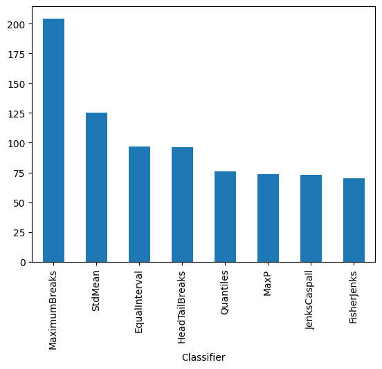

```python
import seaborn
class5 = q5, ei5,msd, ht, mb5, fj5, jc5, mp5
# Collect ADCM for each classifier
fits = np.array([ c.adcm for c in class5])
# Convert ADCM scores to a DataFrame
adcms = pd.DataFrame(fits)
# Add classifier names
adcms['classifier'] = [c.name for c in class5]
# Add column names to the ADCM
adcms.columns = ['ADCM', 'Classifier']
adcms.sort_values(by='ADCM', ascending=False).plot(kind='bar', x='Classifier', y='ADCM', legend=False);
```

Dado que el menor valor de ADCM es el método FisherJenks

```python
fj5
```

```
FisherJenks

   Interval      Count
----------------------
[ 0.30,  2.70] |    26
( 2.70,  4.10] |    52
( 4.10,  5.60] |    55
( 5.60,  7.80] |    36
( 7.80, 12.80] |     7
```

```python
New_dataframe['education_categorie']=pd.cut(New_dataframe['education_expenditure(%GDP)'],bins=[0.3, 2.7, 4.1, 5.6, 7.8, 12.8],labels=['very_low','low','medium','high', 'very_high'],ordered=True, include_lowest=True)
New_dataframe.head()
```

|  | Country | Region | education_expenditure(%GDP) | power_generation(kW) | Btu/person_consumption($) | financial_assets_value($) | education_categorie |
| --- | --- | --- | --- | --- | --- | --- | --- |
| 0 | SOLOMON ISLANDS | AUSTRALIA AND OCEANIA | 12.8 | 37000 | 5655000 | 688220000 | very_high |
| 1 | BOLIVIA | SOUTH AMERICA | 9.8 | 4375000 | 29340000 | 1800000000 | very_high |
| 2 | NAMIBIA | AFRICA | 9.6 | 646000 | 21734000 | 2956000000 | very_high |
| 3 | SIERRA LEONE | AFRICA | 9.1 | 149000 | 2301000 | 495699000 | very_high |
| 4 | BELIZE | CENTRAL AMERICA AND THE CARIBBEAN | 8.7 | 220000 | 30752000 | 473729000 | very_high |

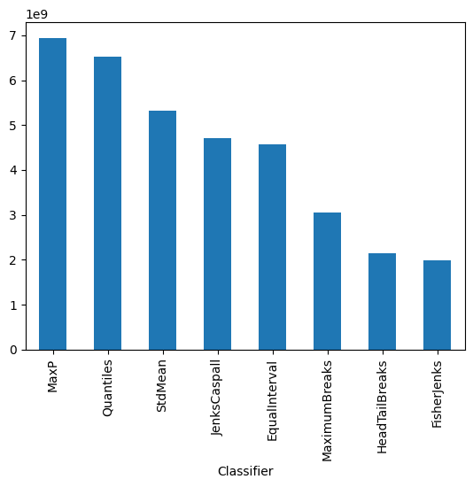

```python
Reconocer=New_dataframe["power_generation(kW)"]
K=5

# Solo divido el intervalo en 5 intervalos de las misma longitud
ei5 = mapclassify.EqualInterval(Reconocer, k=K)
# Distriución normal para hacer intervalos.
msd = mapclassify.StdMean(Reconocer)
# Divides en intervalos de iguales cantidad de observaciones
q5=mapclassify.Quantiles(Reconocer,k=K)
# Crea intervalos en donde los datos son similares entre sí
mb5 = mapclassify.MaximumBreaks(Reconocer, k=K)

ht = mapclassify.HeadTailBreaks(Reconocer)

fj51 = mapclassify.FisherJenks(Reconocer, k=K)

jc5 = mapclassify.JenksCaspall(Reconocer, k=K)

mp5 = mapclassify.MaxP(Reconocer, k=K)
class5 = q5, ei5,msd, ht, mb5, fj51, jc5, mp5
# Collect ADCM for each classifier
fits = np.array([ c.adcm for c in class5])
# Convert ADCM scores to a DataFrame
adcms = pd.DataFrame(fits)
# Add classifier names
adcms['classifier'] = [c.name for c in class5]
# Add column names to the ADCM
adcms.columns = ['ADCM', 'Classifier']
adcms.sort_values(by='ADCM', ascending=False).plot(kind='bar', x='Classifier', y='ADCM', legend=False);
```

```python
fj51
```

```
FisherJenks

           Interval              Count
--------------------------------------
[     29000.00,   47631000.00] |   149
(  47631000.00,  161988000.00] |    20
( 161988000.00,  499136000.00] |     5
( 499136000.00, 1235000000.00] |     1
(1235000000.00, 2949000000.00] |     1
```

```python
New_dataframe['generation_categorie']=pd.cut(New_dataframe['power_generation(kW)'],bins=[29000.00, 47631000.00, 161988000.00, 499136000.00, 1235000000.00, 2949000000.00],labels=['very_low','low','medium','high', 'very_high'],ordered=True, include_lowest=True)
New_dataframe.head()
```

|  | Country | Region | education_expenditure(%GDP) | power_generation(kW) | Btu/person_consumption($) | financial_assets_value($) | education_categorie | generation_categorie |
| --- | --- | --- | --- | --- | --- | --- | --- | --- |
| 0 | SOLOMON ISLANDS | AUSTRALIA AND OCEANIA | 12.8 | 37000 | 5655000 | 688220000 | very_high | very_low |
| 1 | BOLIVIA | SOUTH AMERICA | 9.8 | 4375000 | 29340000 | 1800000000 | very_high | very_low |
| 2 | NAMIBIA | AFRICA | 9.6 | 646000 | 21734000 | 2956000000 | very_high | very_low |
| 3 | SIERRA LEONE | AFRICA | 9.1 | 149000 | 2301000 | 495699000 | very_high | very_low |
| 4 | BELIZE | CENTRAL AMERICA AND THE CARIBBEAN | 8.7 | 220000 | 30752000 | 473729000 | very_high | very_low |

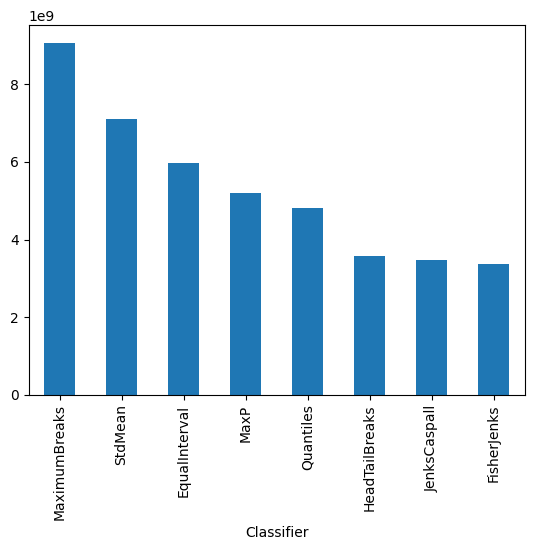

```python
Reconocer=New_dataframe["Btu/person_consumption($)"]
K=5

# Solo divido el intervalo en 5 intervalos de las misma longitud
ei5 = mapclassify.EqualInterval(Reconocer, k=K)
# Distriución normal para hacer intervalos.
msd = mapclassify.StdMean(Reconocer)
# Divides en intervalos de iguales cantidad de observaciones
q5=mapclassify.Quantiles(Reconocer,k=K)
# Crea intervalos en donde los datos son similares entre sí
mb5 = mapclassify.MaximumBreaks(Reconocer, k=K)

ht = mapclassify.HeadTailBreaks(Reconocer)

fj52 = mapclassify.FisherJenks(Reconocer, k=K)

jc5 = mapclassify.JenksCaspall(Reconocer, k=K)

mp5 = mapclassify.MaxP(Reconocer, k=K)
class5 = q5, ei5,msd, ht, mb5, fj52, jc5, mp5
# Collect ADCM for each classifier
fits = np.array([ c.adcm for c in class5])
# Convert ADCM scores to a DataFrame
adcms = pd.DataFrame(fits)
# Add classifier names
adcms['classifier'] = [c.name for c in class5]
# Add column names to the ADCM
adcms.columns = ['ADCM', 'Classifier']
adcms.sort_values(by='ADCM', ascending=False).plot(kind='bar', x='Classifier', y='ADCM', legend=False);
```

```python
fj52
```

```
FisherJenks

          Interval             Count
------------------------------------
[   649000.00,  50886000.00] |    95
( 50886000.00, 143149000.00] |    58
(143149000.00, 278474000.00] |    14
(278474000.00, 450432000.00] |     6
(450432000.00, 814308000.00] |     3
```

```python
New_dataframe['consumption_categorie']=pd.cut(New_dataframe['Btu/person_consumption($)'],bins=[649000.00, 50886000.00, 143149000.00, 278474000.00, 450432000.00, 814308000.00],labels=['very_low','low','medium','high', 'very_high'],ordered=True, include_lowest=True)
New_dataframe.head()
```

|  | Country | Region | education_expenditure(%GDP) | power_generation(kW) | Btu/person_consumption($) | financial_assets_value($) | education_categorie | generation_categorie | consumption_categorie |
| --- | --- | --- | --- | --- | --- | --- | --- | --- | --- |
| 0 | SOLOMON ISLANDS | AUSTRALIA AND OCEANIA | 12.8 | 37000 | 5655000 | 688220000 | very_high | very_low | very_low |
| 1 | BOLIVIA | SOUTH AMERICA | 9.8 | 4375000 | 29340000 | 1800000000 | very_high | very_low | very_low |
| 2 | NAMIBIA | AFRICA | 9.6 | 646000 | 21734000 | 2956000000 | very_high | very_low | very_low |
| 3 | SIERRA LEONE | AFRICA | 9.1 | 149000 | 2301000 | 495699000 | very_high | very_low | very_low |
| 4 | BELIZE | CENTRAL AMERICA AND THE CARIBBEAN | 8.7 | 220000 | 30752000 | 473729000 | very_high | very_low | very_low |

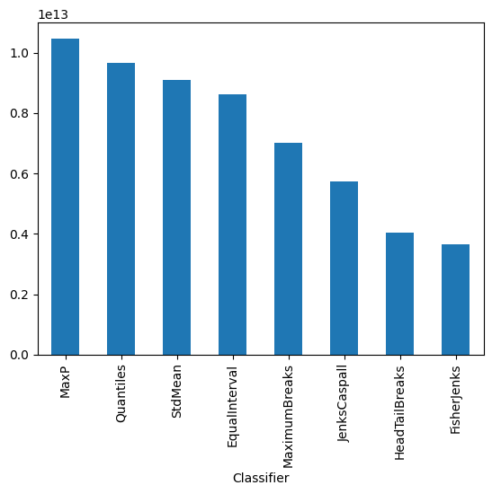

```python
Reconocer=New_dataframe["financial_assets_value($)"]
K=5

# Solo divido el intervalo en 5 intervalos de las misma longitud
ei5 = mapclassify.EqualInterval(Reconocer, k=K)
# Distriución normal para hacer intervalos.
msd = mapclassify.StdMean(Reconocer)
# Divides en intervalos de iguales cantidad de observaciones
q5=mapclassify.Quantiles(Reconocer,k=K)
# Crea intervalos en donde los datos son similares entre sí
mb5 = mapclassify.MaximumBreaks(Reconocer, k=K)

ht = mapclassify.HeadTailBreaks(Reconocer)

fj53 = mapclassify.FisherJenks(Reconocer, k=K)

jc5 = mapclassify.JenksCaspall(Reconocer, k=K)

mp5 = mapclassify.MaxP(Reconocer, k=K)
class5 = q5, ei5,msd, ht, mb5, fj53, jc5, mp5
# Collect ADCM for each classifier
fits = np.array([ c.adcm for c in class5])
# Convert ADCM scores to a DataFrame
adcms = pd.DataFrame(fits)
# Add classifier names
adcms['classifier'] = [c.name for c in class5]
# Add column names to the ADCM
adcms.columns = ['ADCM', 'Classifier']
adcms.sort_values(by='ADCM', ascending=False).plot(kind='bar', x='Classifier', y='ADCM', legend=False);
```

```python
fj53
```

```
FisherJenks

              Interval                 Count
--------------------------------------------
[     30450000.00,   81217000000.00] |   145
(  81217000000.00,  247396000000.00] |    19
( 247396000000.00,  627793000000.00] |     8
( 627793000000.00, 1295000000000.00] |     3
(1295000000000.00, 3450000000000.00] |     1
```

```python
New_dataframe['financial_categorie']=pd.cut(New_dataframe['financial_assets_value($)'],bins=[30450000.00,81217000000.00,247396000000.00, 627793000000.00, 1295000000000.00,3450000000000.00],labels=['very_low','low','medium','high', 'very_high'],ordered=True, include_lowest=True)
New_dataframe.head()
```

|  | Country | Region | education_expenditure(%GDP) | power_generation(kW) | Btu/person_consumption($) | financial_assets_value($) | education_categorie | generation_categorie | consumption_categorie | financial_categorie |
| --- | --- | --- | --- | --- | --- | --- | --- | --- | --- | --- |
| 0 | SOLOMON ISLANDS | AUSTRALIA AND OCEANIA | 12.8 | 37000 | 5655000 | 688220000 | very_high | very_low | very_low | very_low |
| 1 | BOLIVIA | SOUTH AMERICA | 9.8 | 4375000 | 29340000 | 1800000000 | very_high | very_low | very_low | very_low |
| 2 | NAMIBIA | AFRICA | 9.6 | 646000 | 21734000 | 2956000000 | very_high | very_low | very_low | very_low |
| 3 | SIERRA LEONE | AFRICA | 9.1 | 149000 | 2301000 | 495699000 | very_high | very_low | very_low | very_low |
| 4 | BELIZE | CENTRAL AMERICA AND THE CARIBBEAN | 8.7 | 220000 | 30752000 | 473729000 | very_high | very_low | very_low | very_low |

Reordenamos las categorías

```python
cat1 = New_dataframe['education_categorie']
New_dataframe=New_dataframe.drop(columns=['education_categorie'])
New_dataframe.insert(3, 'education_categorie', cat1 )
New_dataframe
```

|  | Country | Region | education_expenditure(%GDP) | education_categorie | power_generation(kW) | Btu/person_consumption($) | financial_assets_value($) | generation_categorie | consumption_categorie | financial_categorie |
| --- | --- | --- | --- | --- | --- | --- | --- | --- | --- | --- |
| 0 | SOLOMON ISLANDS | AUSTRALIA AND OCEANIA | 12.8 | very_high | 37000 | 5655000 | 688220000 | very_low | very_low | very_low |
| 1 | BOLIVIA | SOUTH AMERICA | 9.8 | very_high | 4375000 | 29340000 | 1800000000 | very_low | very_low | very_low |
| 2 | NAMIBIA | AFRICA | 9.6 | very_high | 646000 | 21734000 | 2956000000 | very_low | very_low | very_low |
| 3 | SIERRA LEONE | AFRICA | 9.1 | very_high | 149000 | 2301000 | 495699000 | very_low | very_low | very_low |
| 4 | BELIZE | CENTRAL AMERICA AND THE CARIBBEAN | 8.7 | very_high | 220000 | 30752000 | 473729000 | very_low | very_low | very_low |
| ... | ... | ... | ... | ... | ... | ... | ... | ... | ... | ... |
| 171 | HAITI | CENTRAL AMERICA AND THE CARIBBEAN | 1.4 | very_low | 472000 | 3486000 | 2586000000 | very_low | very_low | very_low |
| 172 | PAPUA NEW GUINEA | EAST AND SOUTHEAST ASIA | 1.4 | very_low | 1148000 | 8781000 | 3901000000 | very_low | very_low | very_low |
| 173 | VENEZUELA | SOUTH AMERICA | 1.3 | very_low | 33493000 | 54474000 | 9794000000 | very_low | low | very_low |
| 174 | NIGERIA | AFRICA | 0.5 | very_low | 4094000 | 7993000 | 35564000000 | very_low | very_low | very_low |
| 175 | SOMALIA | AFRICA | 0.3 | very_low | 156000 | 649000 | 30450000 | very_low | very_low | very_low |

176 rows × 10 columns

```python
cat2 = New_dataframe['generation_categorie']
New_dataframe=New_dataframe.drop(columns=['generation_categorie'])
New_dataframe.insert(5, 'generation_categorie', cat2 )
New_dataframe
```

|  | Country | Region | education_expenditure(%GDP) | education_categorie | power_generation(kW) | generation_categorie | Btu/person_consumption($) | financial_assets_value($) | consumption_categorie | financial_categorie |
| --- | --- | --- | --- | --- | --- | --- | --- | --- | --- | --- |
| 0 | SOLOMON ISLANDS | AUSTRALIA AND OCEANIA | 12.8 | very_high | 37000 | very_low | 5655000 | 688220000 | very_low | very_low |
| 1 | BOLIVIA | SOUTH AMERICA | 9.8 | very_high | 4375000 | very_low | 29340000 | 1800000000 | very_low | very_low |
| 2 | NAMIBIA | AFRICA | 9.6 | very_high | 646000 | very_low | 21734000 | 2956000000 | very_low | very_low |
| 3 | SIERRA LEONE | AFRICA | 9.1 | very_high | 149000 | very_low | 2301000 | 495699000 | very_low | very_low |
| 4 | BELIZE | CENTRAL AMERICA AND THE CARIBBEAN | 8.7 | very_high | 220000 | very_low | 30752000 | 473729000 | very_low | very_low |
| ... | ... | ... | ... | ... | ... | ... | ... | ... | ... | ... |
| 171 | HAITI | CENTRAL AMERICA AND THE CARIBBEAN | 1.4 | very_low | 472000 | very_low | 3486000 | 2586000000 | very_low | very_low |
| 172 | PAPUA NEW GUINEA | EAST AND SOUTHEAST ASIA | 1.4 | very_low | 1148000 | very_low | 8781000 | 3901000000 | very_low | very_low |
| 173 | VENEZUELA | SOUTH AMERICA | 1.3 | very_low | 33493000 | very_low | 54474000 | 9794000000 | low | very_low |
| 174 | NIGERIA | AFRICA | 0.5 | very_low | 4094000 | very_low | 7993000 | 35564000000 | very_low | very_low |
| 175 | SOMALIA | AFRICA | 0.3 | very_low | 156000 | very_low | 649000 | 30450000 | very_low | very_low |

176 rows × 10 columns

```python
cat3 = New_dataframe['consumption_categorie']
New_dataframe=New_dataframe.drop(columns=['consumption_categorie'])
New_dataframe.insert(7, 'consumption_categorie', cat3 )
New_dataframe
```

|  | Country | Region | education_expenditure(%GDP) | education_categorie | power_generation(kW) | generation_categorie | Btu/person_consumption($) | consumption_categorie | financial_assets_value($) | financial_categorie |
| --- | --- | --- | --- | --- | --- | --- | --- | --- | --- | --- |
| 0 | SOLOMON ISLANDS | AUSTRALIA AND OCEANIA | 12.8 | very_high | 37000 | very_low | 5655000 | very_low | 688220000 | very_low |
| 1 | BOLIVIA | SOUTH AMERICA | 9.8 | very_high | 4375000 | very_low | 29340000 | very_low | 1800000000 | very_low |
| 2 | NAMIBIA | AFRICA | 9.6 | very_high | 646000 | very_low | 21734000 | very_low | 2956000000 | very_low |
| 3 | SIERRA LEONE | AFRICA | 9.1 | very_high | 149000 | very_low | 2301000 | very_low | 495699000 | very_low |
| 4 | BELIZE | CENTRAL AMERICA AND THE CARIBBEAN | 8.7 | very_high | 220000 | very_low | 30752000 | very_low | 473729000 | very_low |
| ... | ... | ... | ... | ... | ... | ... | ... | ... | ... | ... |
| 171 | HAITI | CENTRAL AMERICA AND THE CARIBBEAN | 1.4 | very_low | 472000 | very_low | 3486000 | very_low | 2586000000 | very_low |
| 172 | PAPUA NEW GUINEA | EAST AND SOUTHEAST ASIA | 1.4 | very_low | 1148000 | very_low | 8781000 | very_low | 3901000000 | very_low |
| 173 | VENEZUELA | SOUTH AMERICA | 1.3 | very_low | 33493000 | very_low | 54474000 | low | 9794000000 | very_low |
| 174 | NIGERIA | AFRICA | 0.5 | very_low | 4094000 | very_low | 7993000 | very_low | 35564000000 | very_low |
| 175 | SOMALIA | AFRICA | 0.3 | very_low | 156000 | very_low | 649000 | very_low | 30450000 | very_low |

176 rows × 10 columns

```python
New_dataframe.info()
```

```
<class 'pandas.core.frame.DataFrame'>
RangeIndex: 176 entries, 0 to 175
Data columns (total 10 columns):
 #   Column                       Non-Null Count  Dtype
---  ------                       --------------  -----
 0   Country                      176 non-null    object
 1   Region                       176 non-null    object
 2   education_expenditure(%GDP)  176 non-null    float64
 3   education_categorie          176 non-null    category
 4   power_generation(kW)         176 non-null    int64
 5   generation_categorie         176 non-null    category
 6   Btu/person_consumption($)    176 non-null    int64
 7   consumption_categorie        176 non-null    category
 8   financial_assets_value($)    176 non-null    int64
 9   financial_categorie          176 non-null    category
dtypes: category(4), float64(1), int64(3), object(2)
memory usage: 9.9+ KB
```

```python
fj5
```

```
FisherJenks

   Interval      Count
----------------------
[ 0.30,  2.70] |    26
( 2.70,  4.10] |    52
( 4.10,  5.60] |    55
( 5.60,  7.80] |    36
( 7.80, 12.80] |     7
```

```python
fj51
```

```
FisherJenks

           Interval              Count
--------------------------------------
[     29000.00,   47631000.00] |   149
(  47631000.00,  161988000.00] |    20
( 161988000.00,  499136000.00] |     5
( 499136000.00, 1235000000.00] |     1
(1235000000.00, 2949000000.00] |     1
```

```python
fj52
```

```
FisherJenks

          Interval             Count
------------------------------------
[   649000.00,  50886000.00] |    95
( 50886000.00, 143149000.00] |    58
(143149000.00, 278474000.00] |    14
(278474000.00, 450432000.00] |     6
(450432000.00, 814308000.00] |     3
```

```python
fj53
```

```
FisherJenks

              Interval                 Count
--------------------------------------------
[     30450000.00,   81217000000.00] |   145
(  81217000000.00,  247396000000.00] |    19
( 247396000000.00,  627793000000.00] |     8
( 627793000000.00, 1295000000000.00] |     3
(1295000000000.00, 3450000000000.00] |     1
```

Para salvaguardar las columnas category, utilizamos pikle. Pero también en formato csv

```python
New_dataframe.to_csv("countrydata.csv",index=False )
New_dataframe.to_pickle("countrydata.pkl")
```